# **Facial Emotion Detection**

## **Problem Definition**

**The context:** Why is this problem important to solve?

Facial emotion recognition is important for approximating the emotions of the faces captured on camera or video. For instance, if a camera captured a smiley face, it could serve as a signal to automatically capture the smile on the picture. Furthermore, recognizing approximated facial emotions could allow automated response in correlation to be more apt to the person's need, for instance, if an automated machine is responding to questions, and recognizing facial emotions would provide some signals to veer the responses to more considerate and provide better service and "warmer" responses. This would allow better machine-human interactions given that the machine could recognize the facial emotions that are presented as unstructured data.

**The objectives:** What is the intended goal?

For machines to recognize the facial emotions better, given the dataset, it would be a classifier machine learning model. The goal for the model is to find an architecture of the model and weights that could provide optimal performance in classifying facial images into 4 categories: happy, sad, neutral, and surprise.

**The key questions:** What are the key questions that need to be answered?

To proceed to create this machine learning model as a classifier, the key questions for the model would be:

1. The model architecture has to be found that works well with the given image data, that is to say,
   - the depth of the model,
   - the width of the model,
   - the type of layers and how many of each and how they are put together,
   - drop out to be considered,
   - batch normalization to be considered,
   - the optimal activation functions,
   - the optimal weight initializations,
   - if image augmenation for training is needed (i.e. the given image dataset has enough variety and if there are enough samples to train the model on), and
   - the optimal weights for the model
2. The model "optimal" perofrmance would mean that based on the validation accuracy over the training period to, if the validation accuracy is "high" and "optimizaed"
3. Are the image data provided sufficient (varied enough and sample size large enough) and the challenge might even be that if the data is classified correctly enough?

**The problem formulation:** What are we trying to solve using data science?

This is a classification problem on high dimensional unstructured data (image data, could be grayscale or an even higher dimensional data of RGB), so that any unseen image given to the model could be classified into 4 categories (i.e., happy, sad, neutral, and surprise) with efficient model weights and processing.

## **About the dataset**

The data set consists of 3 folders, i.e., 'test', 'train', and 'validation'. Each of these folders has four subfolders:

**‘happy’**: Images of people who have happy facial expressions.  
**‘sad’**: Images of people with sad or upset facial expressions.  
**‘surprise’**: Images of people who have shocked or surprised facial expressions.  
**‘neutral’**: Images of people showing no prominent emotion in their facial expression at all.

## **Mounting the Drive**

**NOTE:** Please use Google Colab from your browser for this notebook. **Google.colab is NOT a library that can be downloaded locally on your device.**

```python
# running via the local computer and local data, not necessary to mount the drive
# see lines below for sample code

# from google.colab import drive
# drive.mount('/content/drive')
```

## **Importing the Libraries**

```python
import h5py # load dataset in h5
import numpy as np # working with numerical operations
import matplotlib.pyplot as plt # visualization
import seaborn as sns # visualization
import tensorflow as tf # machine learining model building
import keras # machine learining model building
from keras.utils.np_utils import to_categorical # transforming datasets
from sklearn.metrics import classification_report, confusion_matrix # evaluations
import random
from tensorflow.keras import backend
from zipfile import ZipFile as zipfile
import os
import pickle
import pandas as pd
from tensorflow.keras import backend

path = os.getcwd()
```

### **Let us load and unzip the data**

**Note:**

- You must download the dataset from the link provided on Olympus and upload the same on your Google drive before executing the code in the next cell.
- In case of any error, please make sure that the path of the file is correct as the path may be different for you.

```python
# unzipping the file
zip_object = zipfile(os.path.join(path,'Facial_emotion_images.zip'), 'r')
# zip_object.printdir()
dir_zip_content = list(zip_object.namelist())[0].split('/')[0] # name of the top folder within zip file
zip_object.extractall(path)
zip_object.close(); del zip_object

# list data available
dir_dsplit = os.listdir(os.path.join(path,dir_zip_content))
print('data split:', dir_dsplit)
for n_dsplit in range(len(dir_dsplit)):
    dir_cat = os.listdir(os.path.join(path,dir_zip_content,dir_dsplit[n_dsplit])) # list data categories
    print('%s:' %(dir_dsplit[n_dsplit]),dir_cat)

# convert the data into a format for easier process
data = {}
for n_dsplit in range(len(dir_dsplit)): # data split folder content
    dir_cat = os.listdir(os.path.join(path,dir_zip_content,dir_dsplit[n_dsplit])) # list data categories
    name_data_split = dir_dsplit[n_dsplit]
    data[name_data_split] = {}
    for n_cat in range(len(dir_cat)): # data class category folder content
        content_split_cat_img = os.listdir(os.path.join(path,dir_zip_content,dir_dsplit[n_dsplit],dir_cat[n_cat])) # list data categories
        name_data_cat = dir_cat[n_cat]
        data[name_data_split].update({name_data_cat:{}})
        for n_img in range(len(content_split_cat_img)): # data image
            path_img = os.path.join(path,dir_zip_content,dir_dsplit[n_dsplit],dir_cat[n_cat],content_split_cat_img[n_img])
            img_now = plt.imread(path_img)
            img_now = np.reshape(img_now,(1,img_now.shape[0],img_now.shape[1]))
            if n_img == 0:
                data_split_cat = img_now
            else:
                data_split_cat = np.concatenate([data_split_cat,img_now], axis=0)
        data[name_data_split].update({name_data_cat: data_split_cat})
        # save data to avoid repeated processing --> a breakpoint for data transformation
        fileID = open(os.path.join(path,'face_emotion.pkl'),'bw')
        pickle.dump(data,fileID)
        fileID.close()
del fileID
```

```
data split: ['test', 'train', 'validation']
test: ['happy', 'neutral', 'sad', 'surprise']
train: ['happy', 'neutral', 'sad', 'surprise']
validation: ['happy', 'neutral', 'sad', 'surprise']
```

## **Visualizing our Classes**

Let's look at our classes.

**Write down your observation for each class. What do you think can be a unique feature of each emotion, that separates it from the remaining classes?**

### **Happy**

**Observations and Insights:**

- Image data shape is 48-pixel-by-48-pixel images, which indicates gray-scale images, rather than RGB images. RGB images would have shown 48-by-48-by-3, where the third dimension would be the different color channels R (red), G (green), and B (blue).
- The images are not very large at 48-pixel-by-48-pixel.
- The images are complex, with some images with:
  - tilted head,
  - non-facial featuers (hair over the face, arms, hats, etc),
  - a range of mouth expressions (e.g., wide open mouth, wider smiles, timid smile, etc),
  - varying zoom level,
  - some eyes are squinted and some are not,
  - some with more prominent eyebrows and some thinner eyebrows,
  - different skin tones,
  - varying brightness/darkness,
  - varying contrast,
  - etc.
- 48-by-48 pixel images to learn these complex and finer features on the faces, especially that very deep CNN models tend to shrink the input data of the image, and even with appropriate paddings, edge pixels are less and less represented, the finer details might not be learned in images with this resolution.
- Since the image data is already so varied, it might not need image augmentation treatment for model training, but this remains to be seen with experimentations.

```
Training data shape for a "happy" class: (3976, 48, 48)
```

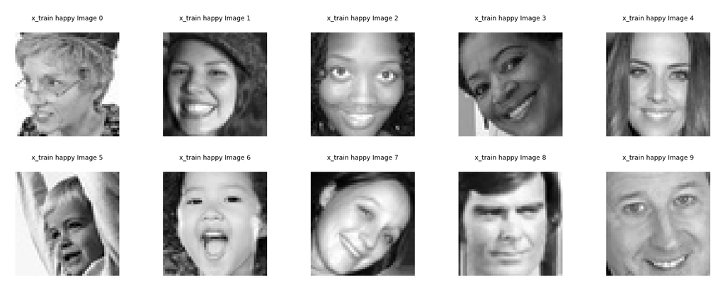

```python
# load saved data
fileID = open(os.path.join(path,'face_emotion.pkl'),'br')
data = pickle.load(fileID)
fileID.close(); del fileID

print('Training data shape for a "happy" class:', data['train']['happy'].shape)

fig = plt.figure(dpi=300,figsize=(5,2))
for i in range(10):
    fig.add_subplot(2,5,i+1)
    plt.imshow(data['train']['happy'][i,:,:],cmap='gray')
    plt.title('x_train happy Image %i' %(i),fontsize=3)
    plt.xticks(fontsize=3)
    plt.yticks(fontsize=3)
    plt.axis('off')
plt.tight_layout()
plt.show()
```

### **Sad**

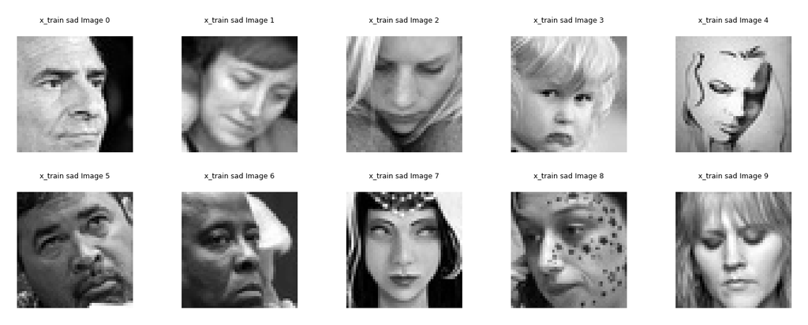

```python
fig = plt.figure(dpi=300,figsize=(5,2))
for i in range(10):
    fig.add_subplot(2,5,i+1)
    plt.imshow(data['train']['sad'][i,:,:],cmap='gray')
    plt.title('x_train sad Image %i' %(i),fontsize=3)
    plt.xticks(fontsize=3)
    plt.yticks(fontsize=3)
    plt.axis('off')
plt.tight_layout()
plt.show()
```

**Observations and Insights:**

- There are a lot of images with head turned to the side instead of front of the face
- The images are complex, as mentioned in the observation for "happy" images.
- Some of the images might be misclassified. As a human looking at some of these, I could easily categorize some of these images as "neutral" or even "frustrated" (not one of the classes), and not "sad"
- None of the "sad" images shown here are actually crying.

### **Neutral**

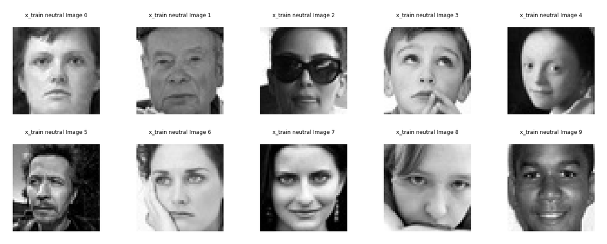

```python
fig = plt.figure(dpi=300,figsize=(5,2))
for i in range(10):
    fig.add_subplot(2,5,i+1)
    plt.imshow(data['train']['neutral'][i,:,:],cmap='gray')
    plt.title('x_train neutral Image %i' %(i),fontsize=3)
    plt.xticks(fontsize=3)
    plt.yticks(fontsize=3)
    plt.axis('off')
plt.tight_layout()
plt.show()
```

**Observations and Insights:**

- Neutral and sad images look very alike. In fact, some of them seem so similar that if I were to be asked, I might have different opinion on the classification.
- There are a lot of images with head turned to the side instead of front of the face
- The images are complex, as mentioned in the observation for "happy" images.

### **Surprised**

[figure not shown]

```python
fig = plt.figure(dpi=300,figsize=(5,2))
for i in range(10):
    fig.add_subplot(2,5,i+1)
    plt.imshow(data['train']['surprise'][i,:,:],cmap='gray')
    plt.title('x_train surprise Image %i' %(i),fontsize=3)
    plt.xticks(fontsize=3)
    plt.yticks(fontsize=3)
    plt.axis('off')
plt.tight_layout()
plt.show()
```

**Observations and Insights:**

- tend to have open mouth and wide-open eyes, many have hands obscuring the facial features leaving only the eyes visible
- The images are complex, as mentioned in the observation for "happy" images.
- Some of the images might be arguably misclassified, some might be categorized as a fifth emotion, "angry" or "aggitated," which is not one of the classes available

## **Checking Distribution of Classes**

```python
# list data available
for n_dsplit in range(len(data.keys())):
    name_split = list(data.keys())[n_dsplit]
    for n_cl in range(len(list(data[name_split]))):
        name_class = list(data[name_split])[n_cl]
        print('%s set "%s" class has %i images' %(name_split,name_class,len(data[name_split][name_class])))
```

```
test set "happy" class has 32 images
test set "neutral" class has 32 images
test set "sad" class has 32 images
test set "surprise" class has 32 images
train set "happy" class has 3976 images
train set "neutral" class has 3978 images
train set "sad" class has 3982 images
train set "surprise" class has 3173 images
validation set "happy" class has 1825 images
validation set "neutral" class has 1216 images
validation set "sad" class has 1139 images
validation set "surprise" class has 797 images
```

**Observations and Insights:**

- The test set has very few samples and equally distributed among all classes, 32 samples in each class. Having so few of them helps quickly assess the performance of trained model.
- The training set the largest samples, all classes have over 3000 samples, however, they are not equally distributed in each class. Total of 15109 samples,
  - 26.3% in class "happy,"
  - 26.3% in class "neutral,"
  - 26.4% in class "sad," and
  - 21.0% in class "surprise,"

where class "surprise" has the least amount of training samples, though, not drastically fewer than the other classes.

- In the training process, due to having fewest samples in "surprise" there might be a small effect, but it may not be noticeable, since the difference in number of samples is not too drastic.
- The validation set has similar issues in sample distribution in each classes as seen in the training set, where there is a total of 4977 samples and
  - 36.7% in class "happy,"
  - 24.4% in class "neutral,"
  - 22.9% in class "sad," and
  - 16.0% in class "surprise."
- Class "happy" has the most amount of samples by more than 10% than classes "neutral" and "sad." "Neutral" and "sad" have similar amount and have more than 6% than class "surprise." More images were pulled to be check on their representations and classes, and the issues of image complexity noted above in class "happy," misclassification, and images that could be multi-class are very noticeable in more samples.

**Think About It:**

- Are the classes equally distributed? If not, do you think the imbalance is too high? Will it be a problem as we progress?

As mentioned in the above observations and comments, there is slight imbalance of the class samples, but the differences are not too great, so it is not a big concern, and I do not perceive it being a model training issue.

- Are there any Exploratory Data Analysis tasks that we can do here? Would they provide any meaningful insights?

I took a more closer look at the data in the above section to visualize the classes, there are a very wide varieties presented in the data, however, there seemed to be some misclassification as well, and this would negatively impact the ability to achieve better learning and higher performance.

## **Creating our Data Loaders**

In this section, we are creating data loaders that we will use as inputs to our Neural Network.

**You have two options for the color_mode. You can set it to color_mode = 'rgb' or color_mode = 'grayscale'. You will need to try out both and see for yourself which one gives better performance.**

```python
# load saved data
fileID = open(os.path.join(path,'face_emotion.pkl'),'br')
data = pickle.load(fileID)
fileID.close(); del fileID

# RANDOMIZE THE DATASET ======================================================================

# merge all labels within split
for n_split in range(len(data.keys())):
    name_split = list(data.keys())[n_split]
    exec('y_'+name_split+' = []')
    exec('x_'+name_split+' = []')
    for n_label in range(len(data[name_split].keys())):
        name_label = list(data[name_split].keys())[n_label]
        for n_img in range(data[name_split][name_label].shape[0]):
            exec('y_'+name_split+'.append(name_label)')
            img_now = data[name_split][name_label][n_img]
            img_now = np.reshape(img_now,(1,img_now.shape[0],img_now.shape[1]))
            if eval('len(x_'+name_split+') == 0'):
                exec('x_'+name_split+' = img_now')
            else:
                exec('x_'+name_split+' = np.concatenate([x_'+name_split+',img_now], axis=0)')

# randomize the input data and label
data_rand = {}
for n_split in range(len(data.keys())):
    name_split = list(data.keys())[n_split]
    exec('rand_key = np.random.choice(np.arange(len(x_'+name_split+')),len(x_'+name_split+'),replace=False)')
    exec('y_'+name_split+'_rand = []')
    exec('x_'+name_split+'_rand = []')
    for i in rand_key:
        exec('y_'+name_split+'_rand.append(y_'+name_split+'[i])')
        img_now = eval('x_'+name_split+'[i]')
        img_now = np.reshape(img_now,(1,img_now.shape[0],img_now.shape[1]))
        if eval('len(x_'+name_split+'_rand) == 0'):
            exec('x_'+name_split+'_rand = img_now')
        else:
            exec('x_'+name_split+'_rand = np.concatenate([x_'+name_split+'_rand,img_now], axis=0)')
    exec('data_rand["x_'+name_split+'"] = x_'+name_split+'_rand')
    exec('data_rand["y_'+name_split+'"] = y_'+name_split+'_rand')

# save the randomized data
fileID = open(os.path.join(path,'face_emotion_random.pkl'),'bw')
pickle.dump(data_rand,fileID)
fileID.close(); del fileID

# DATA PREPARATION FOR MODEL ===========================================================================

# load saved randomized data
fileID = open(os.path.join(path,'face_emotion_random.pkl'),'br')
data = pickle.load(fileID)
fileID.close(); del fileID

# get the split of the data as their own variable
for key in list(data.keys()):
    exec(key+' = data[key]')
del data, key

# numerically represent the labels
classes = pd.unique(y_train)
y_train_cat_num = np.ones(len(y_train))*0.001
y_test_cat_num = np.ones(len(y_test))*0.001
y_val_cat_num = np.ones(len(y_validation))*0.001
key_class = {}
for n_cl in range(len(classes)): # numerical represenation of the class
    print('number %i represents class "%s"' %(n_cl,classes[n_cl]))
    key_class[classes[n_cl]] = n_cl
    for n_tr in range(len(y_train)):
        if y_train[n_tr] == classes[n_cl]:
            y_train_cat_num[n_tr] = n_cl
    for n_ts in range(len(y_test)):
        if y_test[n_ts] == classes[n_cl]:
            y_test_cat_num[n_ts] = n_cl
    for n_val in range(len(y_validation)):
        if y_validation[n_val] == classes[n_cl]:
            y_val_cat_num[n_val] = n_cl

# one-hot representation of the labels
y_train_1hot = to_categorical(y_train_cat_num, num_classes=4) # transforming numerical categoricals into one-hot vectors
y_test_1hot = to_categorical(y_test_cat_num, num_classes=4) # transforming numerical categoricals into one-hot vectors
y_val_1hot = to_categorical(y_val_cat_num, num_classes=4)
print('Training labels now have the shape of',y_train_1hot.shape)
print('Test labels now have the shape of',y_test_1hot.shape)

# normalize and reshape to be model-ready
x_train_norm_4D = np.reshape(x_train/255.0,(x_train.shape[0],x_train.shape[1],x_train.shape[2],1))
x_test_norm_4D = np.reshape(x_test/255.0,(x_test.shape[0],x_test.shape[1],x_test.shape[2],1))
x_validation_norm_4D = np.reshape(x_validation/255.0,(x_validation.shape[0],x_validation.shape[1],x_validation.shape[2],1))

# save the one-hot representation of the randomized data and normalized images to be model-ready
fileID = open(os.path.join(path,'face_emotion_random_1hot.pkl'),'bw')
pickle.dump({'x_train':x_train_norm_4D,'x_test':x_test_norm_4D,'x_validation':x_validation_norm_4D,'y_train':y_train_1hot,'y_test':y_test_1hot,'y_validation':y_val_1hot,'key_class':key_class},fileID)
fileID.close(); del fileID
```

## **Model Building**

**Think About It:**

- Are Convolutional Neural Networks the right approach? Should we have gone with Artificial Neural Networks instead?

CNNs is the right approach, because the image data is so varied with facial expressions at different locations of the image and nuanced details of the facial expressions. ANNs are really good if these facial details do not change locations, however, in reality and in the given image dataset, that is not the case.

- What are the advantages of CNNs over ANNs and are they applicable here?

CNNs can learn local spatiality rather than global spatiality, which in facial emotion recognition is a big advantage, since there are so many different details (e.g., head tilt angles, image and human complexions, non-facial objects, facial obscuration, etc.) that could be learned while they do not always stay in the same locations on the images. Plus, having ANN would make the model very wide, initializing a weight for every pixel, that would be 48*48 = 2304 weights to begin with, while CNN weights are shared through having sliding weight over the convolution process can very efficiently learn patterns on the images that are localized.

### **Creating the Base Neural Network**

```python
# clearing backend
backend.clear_session()

# load saved model-ready data
fileID = open(os.path.join(path,'face_emotion_random_1hot.pkl'),'br')
data = pickle.load(fileID)
fileID.close(); del fileID

# get the split of the data as their own variable & prepare the data for training the model
for key in list(data.keys()):
    exec(key+' = data[key]')
del data, key

print('class representation in numerical values:',key_class)
print('x_train data shape',x_train.shape)
print('y_train data shape',y_train.shape)
print('x_test data shape',x_test.shape)
print('y_test data shape',y_test.shape)
print('x_validation data shape',x_validation.shape)
print('y_validation data shape',y_validation.shape)
print('sample x_train data:\n',x_train[0,:,:,0])
print('sample y_train data:\n',y_train)

# set randomization
np.random.seed(65)
random.seed(65)
tf.random.set_seed(65)

# build the model
input_shape = (48,48,1)
num_classes = 4
model = tf.keras.models.Sequential([
    tf.keras.layers.Conv2D(32,kernel_size=(3,3),strides=(1,1),padding='same',input_shape=input_shape),
    tf.keras.layers.LeakyReLU(alpha=0.1),

    tf.keras.layers.Conv2D(48,kernel_size=(3,3),strides=(1,1),padding='same'),
    tf.keras.layers.LeakyReLU(alpha=0.1),
    tf.keras.layers.MaxPool2D(pool_size=(2,2)),
    tf.keras.layers.BatchNormalization(),

    tf.keras.layers.Conv2D(48,kernel_size=(3,3),strides=(1,1),padding='same'),
    tf.keras.layers.LeakyReLU(alpha=0.1),

    tf.keras.layers.Conv2D(96,kernel_size=(3,3),strides=(1,1),padding='same'),
    tf.keras.layers.LeakyReLU(alpha=0.1),
    tf.keras.layers.MaxPool2D(pool_size=(2,2)),
    tf.keras.layers.BatchNormalization(),

    tf.keras.layers.Flatten(),
    tf.keras.layers.Dense(48),
    tf.keras.layers.LeakyReLU(alpha=0.1),
    tf.keras.layers.Dropout(rate=0.5),

    tf.keras.layers.Dense(num_classes, activation='softmax')])
```

[output not shown]

### **Compiling and Training the Model**

```python
# compile the model
learning_rate = 0.001
model.compile(optimizer=keras.optimizers.Adam(learning_rate=learning_rate),loss='categorical_crossentropy',metrics=['accuracy'])

# rename the model
model_1 = model

# print model summary
model_1.summary()

# fit the model
batch_size = 256
validation_split = 0.2
epoch = 30
history_model_1 = model_1.fit(x=x_train,
                               y=y_train,
                               batch_size=batch_size,
                               epochs=epoch,
                               validation_split=validation_split,
                               verbose=1)

# saving model after training (retain model without having to train again to get the model for reference later)
model_1.save(os.path.join(path,'model_1.h5'))
# save model history
fileID = open(os.path.join(path,'model_1_hist.pkl'),'bw')
pickle.dump({'history_model_1':history_model_1.history},fileID)
fileID.close(); del fileID
```

```
Model: "sequential"
_________________________________________________________________
Layer (type)                 Output Shape              Param #
=================================================================
conv2d (Conv2D)              (None, 48, 48, 32)        320
_________________________________________________________________
leaky_re_lu (LeakyReLU)      (None, 48, 48, 32)        0
_________________________________________________________________
conv2d_1 (Conv2D)            (None, 48, 48, 48)        13872
_________________________________________________________________
leaky_re_lu_1 (LeakyReLU)    (None, 48, 48, 48)        0
_________________________________________________________________
max_pooling2d (MaxPooling2D) (None, 24, 24, 48)        0
_________________________________________________________________
batch_normalization (BatchNo (None, 24, 24, 48)        192
_________________________________________________________________
conv2d_2 (Conv2D)            (None, 24, 24, 48)        20784
_________________________________________________________________
leaky_re_lu_2 (LeakyReLU)    (None, 24, 24, 48)        0
_________________________________________________________________
conv2d_3 (Conv2D)            (None, 24, 24, 96)        41568
_________________________________________________________________
leaky_re_lu_3 (LeakyReLU)    (None, 24, 24, 96)        0
_________________________________________________________________
max_pooling2d_1 (MaxPooling2 (None, 12, 12, 96)        0
_________________________________________________________________
batch_normalization_1 (Batch (None, 12, 12, 96)        384
_________________________________________________________________
flatten (Flatten)            (None, 13824)             0
_________________________________________________________________
dense (Dense)                (None, 48)                663600
_________________________________________________________________
leaky_re_lu_4 (LeakyReLU)    (None, 48)                0
_________________________________________________________________
dropout (Dropout)            (None, 48)                0
_________________________________________________________________
dense_1 (Dense)              (None, 4)                 196
=================================================================
Total params: 740,916
Trainable params: 740,628
Non-trainable params: 288
_________________________________________________________________
```

### **Evaluating the Model on the Test Set**

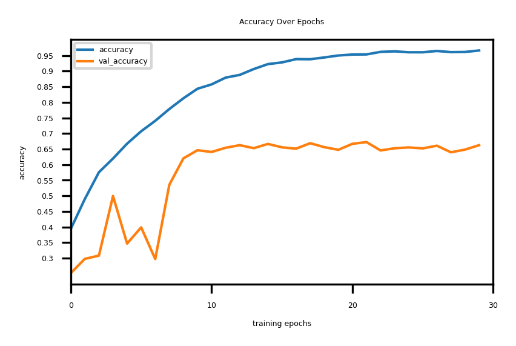

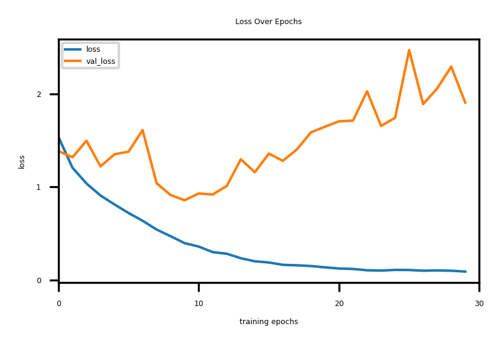

```
Evaluation loss 1.7698224782943726
Evaluation accuracy: 0.7109375
==== Classification report ====

               precision    recall  f1-score   support

           0       0.75      0.84      0.79        32
           1       0.63      0.59      0.61        32
           2       0.89      0.78      0.83        32
           3       0.59      0.62      0.61        32

    accuracy                           0.71       128
   macro avg       0.72      0.71      0.71       128
weighted avg       0.72      0.71      0.71       128

==== Confusion matrix ====

 [[27  2  0  3]
 [ 4 19  1  8]
 [ 1  3 25  3]
 [ 4  6  2 20]]
```

[figure not shown]

```python
# load saved model-ready data
fileID = open(os.path.join(path,'face_emotion_random_1hot.pkl'),'br')
data = pickle.load(fileID)
fileID.close(); del fileID

# get the split of the data as their own variable & prepare the data for training the model
for key in list(data.keys()):
    exec(key+' = data[key]')
del data, key

# load model ======================================
model_1 = tf.keras.models.load_model(os.path.join(path,'model_1.h5'))
# load history
fileID = open(os.path.join(path,'model_1_hist.pkl'),'br')
history_model_1 = pickle.load(fileID)
fileID.close(); del fileID

# TRAINING PROGRESS ============================================
# plot training accuracy
fig = plt.figure(dpi=300,figsize=(3,1.75))
try:
    for key in history_model_1.history.keys():
        if 'accuracy' in key:
            plt.plot(history_model_1.history[key],linewidth=1,label=key)
            plt.xlim([0,len(history_model_1.history[key])])
except:
    for key in history_model_1['history_model_1'].keys():
        if 'accuracy' in key:
            plt.plot(history_model_1['history_model_1'][key],linewidth=1,label=key)
            plt.xlim([0,len(history_model_1['history_model_1'][key])])
plt.ylabel('accuracy',fontsize=3)
plt.xlabel('training epochs',fontsize=3)
plt.xticks(fontsize=3)
plt.yticks(fontsize=3,ticks=np.arange(0.3,1,0.05),labels=np.round(np.arange(0.3,1,0.05),decimals=2))
plt.title('Accuracy Over Epochs',fontsize=3)
plt.legend(fontsize=3)
plt.show()

fig = plt.figure(dpi=300,figsize=(3,1.75))
try:
    for key in history_model_1.history.keys():
        if 'loss' in key:
            plt.plot(history_model_1.history[key],linewidth=1,label=key)
            plt.xlim([0,len(history_model_1.history[key])])
except:
    for key in history_model_1['history_model_1'].keys():
        if 'loss' in key:
            plt.plot(history_model_1['history_model_1'][key],linewidth=1,label=key)
            plt.xlim([0,len(history_model_1['history_model_1'][key])])
plt.ylabel('loss',fontsize=3)
plt.xlabel('training epochs',fontsize=3)
plt.xticks(fontsize=3)
plt.yticks(fontsize=3)
plt.title('Loss Over Epochs',fontsize=3)
plt.legend(fontsize=3)
plt.show()


# test set evaluation ================================================
score = model_1.evaluate(x_test,y_test,verbose=1)
score_names = model_1.metrics_names
print('Evaluation %s' %(score_names[0]), score[0])
print('Evaluation %s:' %(score_names[1]), score[1])

# make prediction
predict_model_1_prob = model_1.predict(x_test)

# converting one-hot back in to class labelss
y_test_class = np.argmax(y_test,axis=1)
predict_model_1_class = np.argmax(predict_model_1_prob,axis=1) # predict (highest probability)

# classification report
print('==== Classification report ====\n\n',classification_report(y_test_class,predict_model_1_class,zero_division=0))

# confusion matrix
print('==== Confusion matrix ====\n\n',confusion_matrix(y_test_class,predict_model_1_class))

fig = plt.figure(dpi=300,figsize=(2,2))
sns.set_style('dark')
cm = confusion_matrix(y_test_class,predict_model_1_class)
sns.heatmap(cm,annot=True,cmap='PiYG',fmt='g',cbar=False,xticklabels=list(key_class.keys()),yticklabels=list(key_class.keys()),annot_kws={"size":6})
plt.title('Confusion Matrix on x_test',fontsize=6)
plt.xlabel('predicted value',fontsize=6)
plt.ylabel('actual value',fontsize=6)
plt.xticks(fontsize=6)
plt.yticks(fontsize=6)
plt.show()
```

**Observations and Insights:**

### **Creating the second Convolutional Neural Network**

- Try out a slightly larger architecture

```python
# clearing backend
backend.clear_session()

# load saved model-ready data
fileID = open(os.path.join(path,'face_emotion_random_1hot.pkl'),'br')
data = pickle.load(fileID)
fileID.close(); del fileID

# get the split of the data as their own variable & prepare the data for training the model
for key in list(data.keys()):
    exec(key+' = data[key]')
del data, key

print('class representation in numerical values:',key_class)
print('x_train data shape',x_train.shape)
print('y_train data shape',y_train.shape)
print('x_test data shape',x_test.shape)
print('y_test data shape',y_test.shape)
print('x_validation data shape',x_validation.shape)
print('y_validation data shape',y_validation.shape)
print('sample x_train data:\n',x_train[0,:,:,0])
print('sample y_train data:\n',y_train)


np.random.seed(103)
random.seed(103)
tf.random.set_seed(103)

# build the model
input_shape = (48,48,1)
num_classes = 4
leaky_relu_slope = 0.1
dropout_rate = 0.5
model = tf.keras.models.Sequential([
    tf.keras.layers.Conv2D(64,kernel_size=(3,3),strides=(1,1),padding='same',input_shape=input_shape),#,kernel_initializer=wgt_init),
    tf.keras.layers.LeakyReLU(alpha=leaky_relu_slope),
    tf.keras.layers.MaxPool2D(pool_size=(2,2),strides=(2,2)),
    tf.keras.layers.BatchNormalization(),

    tf.keras.layers.Conv2D(128,kernel_size=(3,3),strides=(1,1),padding='same'),#,kernel_initializer=wgt_init),
    tf.keras.layers.LeakyReLU(alpha=leaky_relu_slope),
    tf.keras.layers.MaxPool2D(pool_size=(2,2),strides=(2,2)),
    tf.keras.layers.BatchNormalization(),

    tf.keras.layers.Conv2D(256,kernel_size=(3,3),strides=(1,1),padding='same'),#,kernel_initializer=wgt_init),
    tf.keras.layers.LeakyReLU(alpha=leaky_relu_slope),
    tf.keras.layers.MaxPool2D(pool_size=(2,2),strides=(2,2)),
    tf.keras.layers.BatchNormalization(),

    tf.keras.layers.Dropout(rate=dropout_rate),
    tf.keras.layers.Flatten(),
    tf.keras.layers.Dense(4096),
    tf.keras.layers.LeakyReLU(alpha=leaky_relu_slope),

    tf.keras.layers.Dropout(rate=dropout_rate),
    tf.keras.layers.Flatten(),
    tf.keras.layers.Dense(1024),
    tf.keras.layers.LeakyReLU(alpha=leaky_relu_slope),

    tf.keras.layers.Dense(num_classes, activation='softmax')])
```

```
class representation in numerical values: {'happy': 0, 'neutral': 1, 'surprise': 2, 'sad': 3}
x_train data shape (15109, 48, 48, 1)
y_train data shape (15109, 4)
x_test data shape (128, 48, 48, 1)
y_test data shape (128, 4)
x_validation data shape (4977, 48, 48, 1)
y_validation data shape (4977, 4)
sample x_train data:
 [[0.1254902  0.1254902  0.12156863 ... 0.1372549  0.21960784 0.20392157]
 [0.14117647 0.12156863 0.11372549 ... 0.11372549 0.14509804 0.21176471]
 [0.25098039 0.25490196 0.1254902  ... 0.10196078 0.09411765 0.12941176]
 ...
 [0.02745098 0.         0.00784314 ... 0.00784314 0.05882353 0.10588235]
 [0.00784314 0.02352941 0.05098039 ... 0.03529412 0.02745098 0.03529412]
 [0.03529412 0.0745098  0.07843137 ... 0.03921569 0.02352941 0.01960784]]
sample y_train data:
 [[1. 0. 0. 0.]
 [0. 1. 0. 0.]
 [0. 0. 1. 0.]
 ...
 [1. 0. 0. 0.]
 [0. 0. 1. 0.]
 [0. 0. 0. 1.]]
```

### **Compiling and Training the Model**

```python
# compile the model
learning_rate = 0.001
model.compile(optimizer=keras.optimizers.Adam(learning_rate=learning_rate),loss='categorical_crossentropy',metrics=['accuracy'])

# rename the model
model_2 = model

# print model summary
model_2.summary()

# fit the model
batch_size = 256
validation_split = 0.2
epoch = 30
history_model_2 = model_2.fit(x=x_train,
                               y=y_train,
                               batch_size=batch_size,
                               epochs=epoch,
                               validation_split=validation_split,
                               verbose=1)

# saving model after training (retain model without taking the time to train again to get the model)
model_2.save(os.path.join(path,'model_2.h5'))
# save model history
fileID = open(os.path.join(path,'model_2_hist.pkl'),'bw')
pickle.dump({'history_model_2':history_model_2.history},fileID)
fileID.close(); del fileID
```

```
Model: "sequential"
_________________________________________________________________
Layer (type)                 Output Shape              Param #
=================================================================
conv2d (Conv2D)              (None, 48, 48, 64)        640
_________________________________________________________________
leaky_re_lu (LeakyReLU)      (None, 48, 48, 64)        0
_________________________________________________________________
max_pooling2d (MaxPooling2D) (None, 24, 24, 64)        0
_________________________________________________________________
batch_normalization (BatchNo (None, 24, 24, 64)        256
_________________________________________________________________
conv2d_1 (Conv2D)            (None, 24, 24, 128)       73856
_________________________________________________________________
leaky_re_lu_1 (LeakyReLU)    (None, 24, 24, 128)       0
_________________________________________________________________
max_pooling2d_1 (MaxPooling2 (None, 12, 12, 128)       0
_________________________________________________________________
batch_normalization_1 (Batch (None, 12, 12, 128)       512
_________________________________________________________________
conv2d_2 (Conv2D)            (None, 12, 12, 256)       295168
_________________________________________________________________
leaky_re_lu_2 (LeakyReLU)    (None, 12, 12, 256)       0
_________________________________________________________________
max_pooling2d_2 (MaxPooling2 (None, 6, 6, 256)         0
_________________________________________________________________
batch_normalization_2 (Batch (None, 6, 6, 256)         1024
_________________________________________________________________
dropout (Dropout)            (None, 6, 6, 256)         0
_________________________________________________________________
flatten (Flatten)            (None, 9216)              0
_________________________________________________________________
dense (Dense)                (None, 4096)              37752832
_________________________________________________________________
leaky_re_lu_3 (LeakyReLU)    (None, 4096)              0
_________________________________________________________________
dropout_1 (Dropout)          (None, 4096)              0
_________________________________________________________________
flatten_1 (Flatten)          (None, 4096)              0
_________________________________________________________________
dense_1 (Dense)              (None, 1024)              4195328
_________________________________________________________________
leaky_re_lu_4 (LeakyReLU)    (None, 1024)              0
_________________________________________________________________
dense_2 (Dense)              (None, 4)                 4100
=================================================================
Total params: 42,323,716
Trainable params: 42,322,820
Non-trainable params: 896
_________________________________________________________________
```